# Analysis on Github commits (2016-2017)

Analysis with statistical inference on data about commits made to Github from 2016 to 2017

José Benardi de Souza Nunes

10/07/2018

# Introduction

> The code and data employed here can be found at the [original repository](https://github.com/Benardi/commits_on_github). The data employed on this report is a sample of the commits made on some of the repositories on Github each day from 2016 to 2017.

# Data Overview

```r
readr::read_csv(here::here("data/github-users-committing-filetypes.csv"),
                      progress = FALSE,
                      col_types = cols(
                        file_extension = col_character(),
                        month_day = col_integer(),
                        the_month = col_integer(),
                        the_year = col_integer(),
                        users = col_integer()
                        )) -> data
data %>%
  glimpse()
```

```
Observations: 13,802
Variables: 5
$ file_extension <chr> "md", "md", "md", "md", "md", "md", "md", "md", "md", "md", "md", ...
$ month_day      <int> 18, 17, 27, 16, 26, 21, 4, 22, 23, 1, 12, 3, 2, 21, 26, 22, 19, 25...
$ the_month      <int> 2, 2, 1, 2, 1, 3, 2, 2, 2, 2, 4, 2, 2, 2, 4, 3, 4, 1, 3, 4, 2, 3, ...
$ the_year       <int> 2016, 2016, 2016, 2016, 2016, 2017, 2016, 2016, 2016, 2016, 2016, ...
$ users          <int> 10279, 10208, 10118, 10045, 10020, 10015, 9991, 9962, 9959, 9946, ...
```

## Popularity

> We will refer to popularity as the median number of users that commited files of a certain language. In other words, **the more people commit files in a programming language the more popular it is.**

## Is it Weekend yet?

- We will recreate a date object based on the data-frame columns (month_day, the_month, the_year) and from this date object deduce whether the day of that observation was a weekend day or not (**isWeekend**).

```r
data %>%
  mutate(cronology = lubridate::ymd(paste(the_year,
                         the_month,
                         month_day)),
         isWeekend = timeDate::isWeekend(cronology)) -> data
data %>%
  sample_n(10)
```

| file_extension | month_day | the_month | the_year | users | cronology | isWeekend |
| --- | --- | --- | --- | --- | --- | --- |
| svg | 1 | 4 | 2017 | 501 | 2017-04-01 | TRUE |
| svg | 6 | 10 | 2016 | 666 | 2016-10-06 | FALSE |
| lock | 13 | 6 | 2016 | 682 | 2016-06-13 | FALSE |
| cs | 1 | 10 | 2016 | 677 | 2016-10-01 | TRUE |
| py | 15 | 12 | 2016 | 4632 | 2016-12-15 | FALSE |
| csproj | 19 | 9 | 2016 | 556 | 2016-09-19 | FALSE |
| cpp | 22 | 2 | 2017 | 1889 | 2017-02-22 | FALSE |
| go | 14 | 2 | 2017 | 1102 | 2017-02-14 | FALSE |
| c | 25 | 1 | 2016 | 1787 | 2016-01-25 | FALSE |
| h | 22 | 4 | 2017 | 1019 | 2017-04-22 | TRUE |

## All file extensions

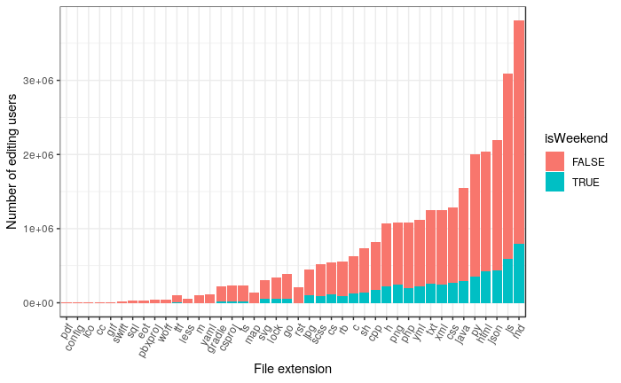

```r
data %>%
  group_by(file_extension, isWeekend) %>%
  summarise(popularity = sum(users)) %>%
  ggplot(aes(x=reorder(file_extension,popularity),
             y = popularity,
             fill=isWeekend)) +
  geom_bar(stat="identity") +
  theme(axis.text.x = element_text(angle=60, hjust=1)) +
  labs(x="File extension",y="Number of editing users")
```

- A lot of md and web related files (json, js, html) were committed on weekends. Looks like documenting and working on the front-end goes on during weekends, poor front-end developers…

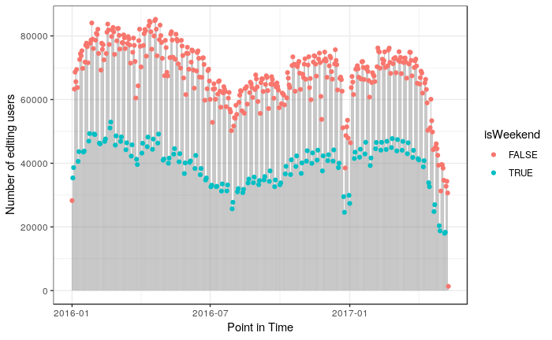

```r
data %>%
  group_by(cronology,isWeekend) %>%
  summarise(popularity = sum(users)) %>%
  ggplot(aes(popularity,cronology,color=isWeekend)) +
  geom_segment(aes(x = 0, y = cronology,
                 xend = popularity,
                 yend = cronology),
               color = "grey50",
               size=0.15) +
  geom_point() +
  coord_flip() +
  labs(y="Point in Time",
       x="Number of editing users")
```

- We can see a sizable decrease in user’s commits around January, this matches typical holidays.

## Python and Java

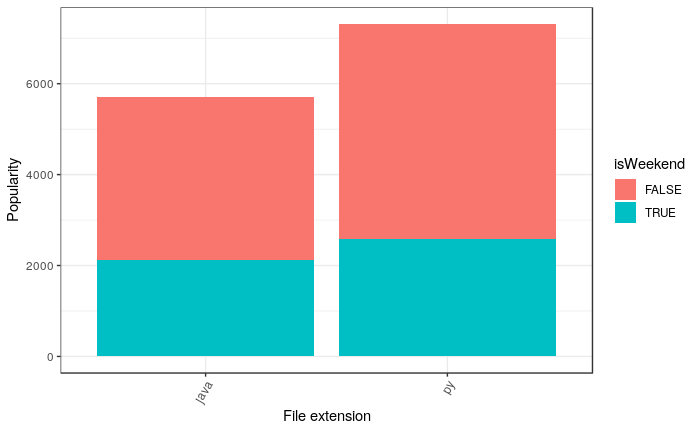

```r
data %>%
  filter(file_extension %in% c("py","java")) %>%
  group_by(file_extension, isWeekend) %>%
  summarise(popularity = median(users)) %>%
  ggplot(aes(x=reorder(file_extension,popularity),
             y = popularity,
             fill=isWeekend)) +
  geom_bar(stat="identity") +
  theme(axis.text.x = element_text(angle=60, hjust=1)) +
  labs(x="File extension",y="Popularity")
```

- In terms of **sample** Python seems to be more popular on weekends than Java.
- In terms of **sample** both Java and Python seem to more popular on weekdays than on weekends.

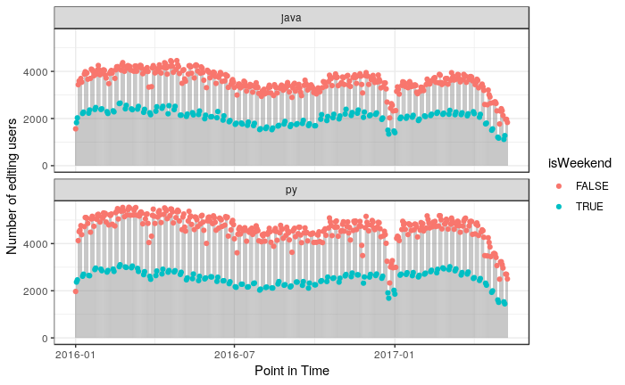

```r
data %>%
  filter(file_extension %in% c("py","java")) %>%
  ggplot(aes(users,cronology,color=isWeekend)) +
  geom_segment(aes(x = 0, y = cronology,
                 xend = users,
                 yend = cronology),
               color = "grey50",
               size=0.15) +
  geom_point() +
  facet_wrap(~ file_extension,
             nrow = 2) +
  coord_flip() +
  labs(y="Point in Time",
       x="Number of editing users")
```

- Both Python and Java reflect the same drop on file editions around January.

# Statistical Inference

> As talking about the **sample** isn’t enough to draw conclusions about the population (coders in Github), further into this report we will make use of **statistical inference**.

## Java

### Overview

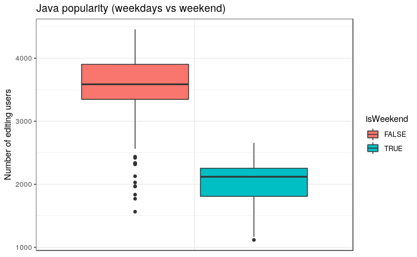

```r
data %>%
  filter(file_extension == "java") %>%
  ggplot(aes(x="",
             y=users,
             group=isWeekend,
             fill=isWeekend)) +
  geom_boxplot() +
  labs(y="Number of editing users") +
  ggtitle("Java popularity (weekdays vs weekend)") +
  theme(axis.title.x=element_blank(),
        axis.text.x=element_blank(),
        axis.ticks.x=element_blank())
```

- In terms of **sample** we see more clearly that Java coders work way more during the week.

### Inference on two samples

- We will make use of confidence intervals at a 95% degree of confidence

```r
data %>%
  filter(file_extension == "java") %>%
  filter(!isWeekend) %>%
  bootstrap(median(users), R = 10000) %>%
    CI.percentile(probs = c(.025, .975)) -> java.week
data %>%
  filter(file_extension == "java") %>%
  filter(isWeekend) %>%
  bootstrap(median(users), R = 10000) %>%
    CI.percentile(probs = c(.025, .975)) -> java.weekend
cat(paste("Java on week days:\n"))
```

```
Java on week days:
```

```r
java.week
```

```
              2.5%  97.5%
median(users) 3533 3665.5
```

```r
cat(paste("\n\nJava on weekend days:\n"))
```

```
Java on weekend days:
```

```r
java.weekend
```

```
              2.5% 97.5%
median(users) 2058  2167
```

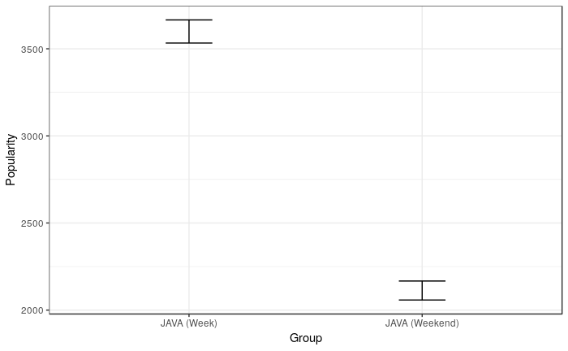

```r
df = data.frame(rbind(java.week,
                      java.weekend[rownames(java.weekend),]))
df$medida = c("JAVA (Week)", "JAVA (Weekend)")
df %>%
  ggplot(aes(x = medida, ymin = X2.5., ymax = X97.5.)) +
  geom_errorbar(width = .2) +
  labs(y= "Popularity", x="Group")
```

> Looking at the confidence intervals (C.I.) of Java popularity during the week and during the weekend **we can say at a 95% degree of confidence that there’s a statistically significant difference between Java popularity during the week and the weekend.**

### Inference on the unpaired difference of two samples

- Let’s bootstrap the unpaired difference between java popularity during the week and java popularity during the weekend.

```r
data %>%
  filter(file_extension == "java") -> java
b.diff.means <- bootstrap2(java$users,
                          treatment = java$isWeekend,
                          median, R = 10000)
means.diff = CI.percentile(b.diff.means, probs = c(.025, .975))
means.diff
```

```
                   2.5%    97.5%
median: FALSE-TRUE 1390 1562.829
```

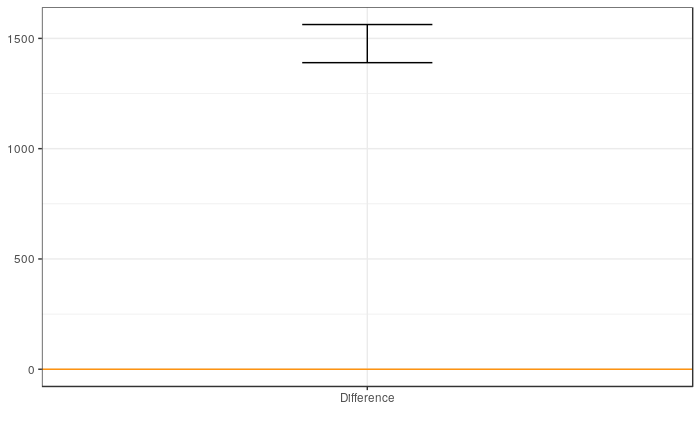

```r
data.frame(means.diff) %>%
  ggplot(aes(x = "Difference",ymin = X2.5., ymax = X97.5.)) +
  geom_errorbar(width = .2) +
  geom_hline(yintercept = 0, colour = "darkorange") +
  labs(x="")
```

- The C.I shows us that Java is more popular during the week (Interval is exclusively above 0). This was expected given the business feel around the Java community.

> Looking at the confidence intervals (C.I.) of the unpaired difference between java popularity on the week and java popularity during the weekend **we can say at a 95% degree of confidence that Java is more popular during the week than during the weekend**.

## Python

### Overview

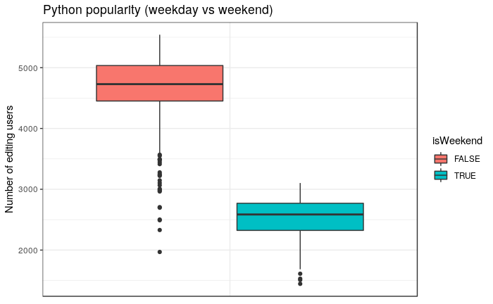

```r
data %>%
  filter(file_extension == "py") %>%
  ggplot(aes(x="",
             y=users,
             group=isWeekend,
             fill=isWeekend)) +
  geom_boxplot() +
  labs(x="", y="Number of editing users") +
  ggtitle("Python popularity (weekday vs weekend)") +
  theme(axis.title.x=element_blank(),
        axis.text.x=element_blank(),
        axis.ticks.x=element_blank())
```

- In terms of **sample** we see more clearly that Python coders work way more during the week.

### Inference on two samples

```r
data %>%
  filter(file_extension == "py") %>%
  filter(!isWeekend) %>%
  bootstrap(median(users), R = 10000) %>%
    CI.percentile(probs = c(.025, .975)) -> python.week
data %>%
  filter(file_extension == "py") %>%
  filter(isWeekend) %>%
  bootstrap(median(users), R = 10000) %>%
    CI.percentile(probs = c(.025, .975)) -> python.weekend
cat(paste("Python on week days:\n"))
```

```
Python on week days:
```

```r
python.week
```

```
              2.5% 97.5%
median(users) 4670  4791
```

```r
cat(paste("\n\nPython on weekend days:\n"))
```

```
Python on weekend days:
```

```r
python.weekend
```

```
                2.5% 97.5%
median(users) 2520.5  2643
```

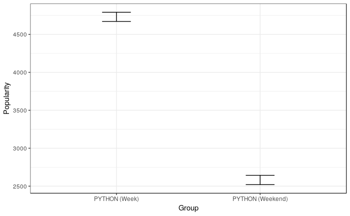

```r
df = data.frame(rbind(python.week,
                      python.weekend[rownames(python.week),]))
df$medida = c("PYTHON (Week)", "PYTHON (Weekend)")
df %>%
  ggplot(aes(x = medida, ymin = X2.5., ymax = X97.5.)) +
  geom_errorbar(width = .2) +
  labs(y= "Popularity", x="Group")
```

> Looking at the confidence intervals (C.I.) of Python popularity during the week and the weekend **we can say at a 95% degree of confidence that there’s a statistically significant difference between Python popularity during the week and Python popularity during the weekend.**

### Inference on the unpaired difference of two samples

- Let’s bootstrap the unpaired difference between Python popularity during the week and Python popularity during the weekend.

```r
data %>%
  filter(file_extension == "py") -> python
b.diff.means <- bootstrap2(python$users,
                          treatment = python$isWeekend,
                          median, R = 10000)
means.diff = CI.percentile(b.diff.means, probs = c(.025, .975))
means.diff
```

```
                   2.5%  97.5%
median: FALSE-TRUE 2062 2234.5
```

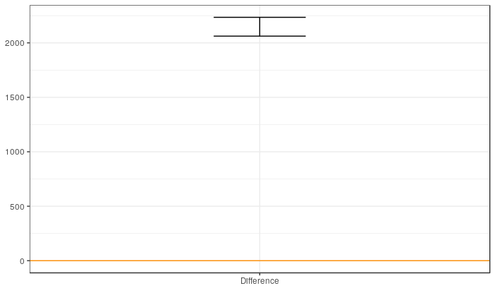

```r
data.frame(means.diff) %>%
  ggplot(aes(x = "Difference",ymin = X2.5., ymax = X97.5.)) +
  geom_errorbar(width = .2) +
  geom_hline(yintercept = 0, colour = "darkorange") +
  labs(x="")
```

- The C.I shows us that Python is more popular during the week than during the weekend (Interval is exclusively above 0).
- The former was not unexpected to be honest, given that there’s a whole business segment around Python despite its carefree vibes.

> Looking at the confidence interval (C.I.) of the unpaired difference between Python popularity during the week and Python popularity during weekends **we can say at a 95% degree of confidence that Python is significantly more popular during the week than during the weekend**.

## Python/Java on the weekend

### Overview

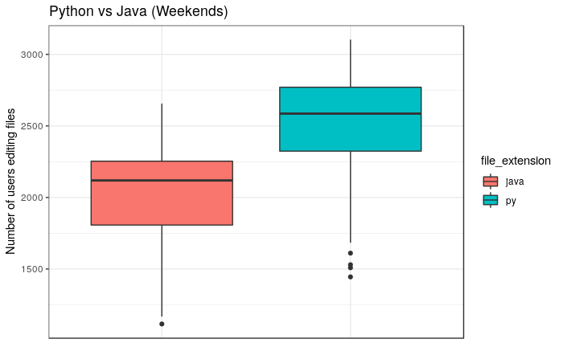

```r
data %>%
  filter(isWeekend) %>%
  filter(file_extension %in% c("py","java")) %>%
  ggplot(aes(x=file_extension,
             y=users,
             group=file_extension,
             fill=file_extension)) +
  geom_boxplot() +
  ggtitle("Python vs Java (Weekends)") +
    theme(axis.title.x=element_blank(),
        axis.text.x=element_blank(),
        axis.ticks.x=element_blank()) +
  labs(y="Number of users editing files")
```

- In terms of **sample** we see more clearly that Python is more popular on weekends than Java.

### Inference on two samples

```r
cat(paste("Java on weekend days:\n"))
```

```
Java on weekend days:
```

```r
java.weekend
```

```
              2.5% 97.5%
median(users) 2058  2167
```

```r
cat(paste("\n\nPython on weekend days:\n"))
```

```
Python on weekend days:
```

```r
python.weekend
```

```
                2.5% 97.5%
median(users) 2520.5  2643
```

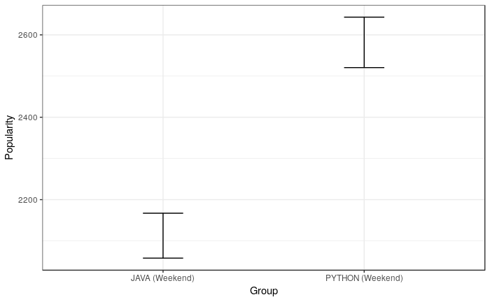

```r
df = data.frame(rbind(java.weekend,
                      python.weekend[rownames(python.week),]))
df$medida = c("JAVA (Weekend)", "PYTHON (Weekend)")
df %>%
  ggplot(aes(x = medida, ymin = X2.5., ymax = X97.5.)) +
  geom_errorbar(width = .2) +
  labs(y= "Popularity", x="Group")
```

> Looking at the confidence intervals (C.I.) of Java and Python popularity during the weekend **we can say at a 95% degree of confidence that there’s a statistically significant difference between Java and Python popularity during the weekend.**

### Inference on the unpaired difference of two samples

- Let’s bootstrap the unpaired difference between Java and Python popularity during the weekend.

```r
data %>%
  filter(isWeekend) %>%
  filter(file_extension %in% c("py","java")) -> weekend
b.diff.means <- bootstrap2(weekend$users,
                          treatment = weekend$file_extension,
                          median, R = 10000)
means.diff = CI.percentile(b.diff.means, probs = c(.025, .975))
means.diff
```

```
                  2.5%  97.5%
median: java-py -549.5 -383.5
```

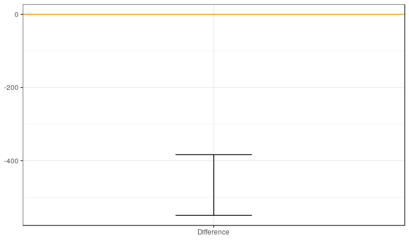

```r
data.frame(means.diff) %>%
  ggplot(aes(x = "Difference",ymin = X2.5., ymax = X97.5.)) +
  geom_errorbar(width = .2) +
  geom_hline(yintercept = 0, colour = "darkorange") +
  labs(x="")
```

- The C.I shows us that Python is more popular than Java during the weekend (Interval is exclusively below 0).
- Python has a much more carefree vibe to it than Java (which is heavily tied to a business environment). It comes as no surprise that people would rather use Python on the weekend.

> Looking at the confidence intervals (C.I.) of the unpaired difference between Java and Python popularity during the weekend **we can say at a 95% degree of confidence that Python is significantly more popular during the weekend than Java**.